# MUSA500 - HW5 K-Means Clustering

Chenxi Zhu, Teresa Chang, and Tiffany Luo

2023-12-08

## 1 Introduction

This assignment aims to utilize k-means clustering to analyze and interpret a dataset of 1720 block groups from Philadelphia. The dataset encompasses five key variables: median house value `MEDHVAL`, median household income `MEDHHINC`, the percentage of individuals with at least a bachelor’s degree `PCTBACHMOR`, the percentage of single/detached housing units `PCTSINGLES`, and the percentage of vacant housing units `PCTVACANT`. By applying k-means clustering, which is a method for identifying and grouping similar data points in multi-dimensional space (see Methods for more detail), we can uncover patterns and relationships within the data. This analysis could reveal the various homeowner categories within the Philadelphia block groups, the number of distinct classes present, and their defining characteristics. Additionally, by incorporating spatial data, it could uncover whether these classes are geographically clustered, which would enable a deeper understanding of the city’s socio-economic landscape. Such insights could be instrumental in shaping city policies

## 2 Methods

### 2.1 K-means algorithm

K-means clustering is a widely used method of unsupervised learning, primarily used for grouping data into clusters. The aim is to partition a set of observations into a specified number k of clusters, where each observation belongs to the cluster with the nearest mean. This method is particularly effective for identifying groups or patterns in large, multi-dimensional datasets. The following steps detail how the algorithm works:

1. **Initialization**: K-means starts by randomly selecting k initial centroids, where k is the predetermined number of clusters.
   - In r, we could use the `Nbclust` package which provides up to 30 indexes for determining the optimal number of clusters in a dataset. Some indexes include the D-index which calculates the second differences of the within-cluster variances for different numbers of clusters, and the Hubert Index which compares the pairwise distances of data points to the clusters they are assigned to (A higher Hubert Index value indicates a better clustering structure, where data points within the same cluster are closer to each other, and those in different clusters are farther apart)..
   - We could visualize the indexes using the scree plot, a line graph showing the number of clusters against a criterion, typically within-cluster sum of squares, helps visualize where the decrease in this criterion becomes less steep. This point, often referred to as the “elbow”, can be a good choice for the number of clusters.
2. **Assignment**: Each data point is assigned to the nearest centroid, based on the distance between the data point and the centroids.
3. **Update**: Centroids are recalculated as the mean of all data points assigned to that cluster.
4. **Iteration**: Steps 2 and 3 are repeated until the centroids no longer change significantly, indicating that the clusters are as homogenous as possible within themselves and heterogeneous from each other.

### 2.2 Limitations of K-means algorithm

K-means clustering, while popular, has limitations. It requires pre-specifying the number of clusters (K), which can be nontrivial without prior knowledge of the data structure. It’s best suited for numeric data and may not perform well with binary variables. K-means may also falter when dealing with clusters of varying sizes, densities, or non-spherical shapes. It’s sensitive to noise and outliers, which can skew results. Additionally, k-means is prone to finding local optima of the sum of squared errors (SSE) rather than the global optimum, which can lead to suboptimal clustering solutions.

### 2.3 Other algorithm

Alternative methods like hierarchical clustering doesn’t have some of the limitations of k-means and doesn’t need to input the number of cluster but it doesn’t work so well with larger data sets. DBSCAN is another algorithm that might be useful that can find arbitrarily shaped clusters and can handle clusters of varying sizes. DBSCAN is particularly good at identifying outliers as noise, which can be advantageous if the dataset contains many outliers that might otherwise skew the results of k-means. It’s also worth considering that DBSCAN requires careful selection of two parameters: `eps`, which defines the maximum distance between two points for one to be considered as in the neighborhood of the other, and `minPts`, the minimum number of points to form a dense region. These parameters are critical to the performance of DBSCAN and must be chosen appropriately for the data at hand. We are sticking with k-means clustering due to its simlicity in this report.

## 3 Results

### 3.1 Choosing the number of clusters k

In the scree plot, the drops in within groups sum of squares in the first few number of clusters are pretty substantial and the drop becomes steady around 5 clusters. The result from the `NbClust` command where 26 criteria are used to determine the best number of clusters shows that 2 is the best number of clusters, followed by 15, 3, and 4.

Dividing the city into just two clusters might be too coarse, potentially oversimplifying the spatial dynamics. Conversely, 15 clusters might result in an overly fragmented view of the city, which could be too detailed for certain analyses or applications. Therefore, choosing 4 clusters appears to be a compromise that balances statistical insight with practical applicability.

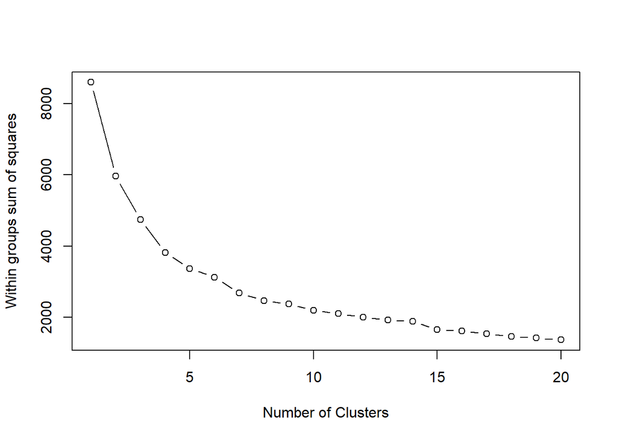

```r
set.seed(2)
data <- read.csv("RegressionData.csv")

vars <- c('MEDHVAL',    'PCTBACHMOR',   'MEDHHINC', 'PCTVACANT',    'PCTSINGLES')
data[vars] <- scale(data[vars])

wss <- (nrow(data[vars])-1)*sum(apply(data[vars],2,var))
for (i in 2:20) wss[i] <- sum(kmeans(data[vars],
                                     centers=i)$withinss)
plot(1:20, wss, type="b", xlab="Number of Clusters",
     ylab="Within groups sum of squares")
```

```r
set.seed(2)
nc <- NbClust(data[vars], min.nc=2, max.nc=15, method="kmeans", index="all")
```

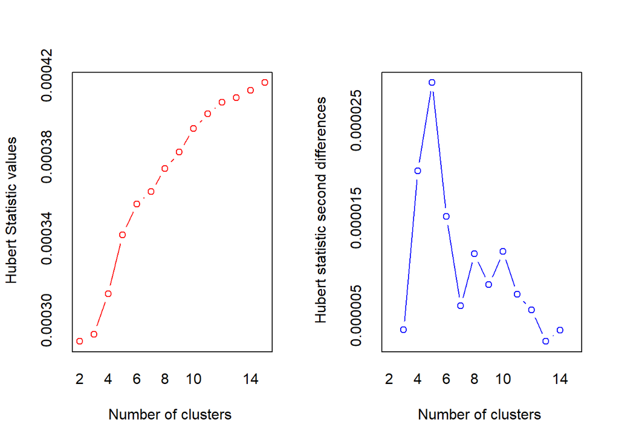

```
## *** : The Hubert index is a graphical method of determining the number of clusters.
##                 In the plot of Hubert index, we seek a significant knee that corresponds to a
##                 significant increase of the value of the measure i.e the significant peak in Hubert
##                 index second differences plot.
##
```

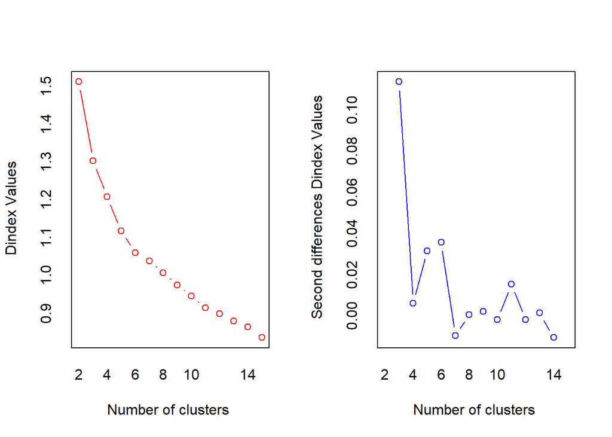

```
## *** : The D index is a graphical method of determining the number of clusters.
##                 In the plot of D index, we seek a significant knee (the significant peak in Dindex
##                 second differences plot) that corresponds to a significant increase of the value of
##                 the measure.
##
## * Among all indices:
## * 8 proposed 2 as the best number of clusters
## * 3 proposed 3 as the best number of clusters
## * 3 proposed 4 as the best number of clusters
## * 2 proposed 7 as the best number of clusters
## * 1 proposed 8 as the best number of clusters
## * 1 proposed 9 as the best number of clusters
## * 6 proposed 15 as the best number of clusters
##
##                    ***** Conclusion *****
##
## * According to the majority rule, the best number of clusters is  2
##
##
```

```r
table(nc$Best.n[1,])
```

```
##
##  0  2  3  4  7  8  9 15
##  2  8  3  3  2  1  1  6
```

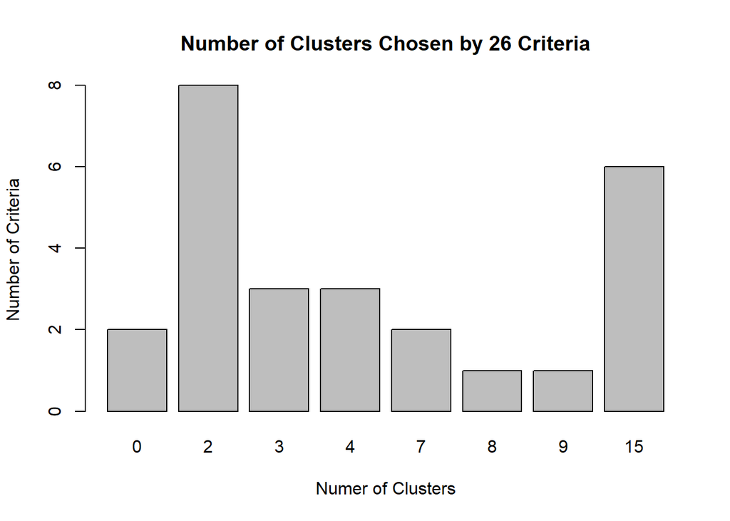

```r
par(mfrow=c(1,1))
barplot(table(nc$Best.n[1,]),
        xlab="Numer of Clusters", ylab="Number of Criteria",
        main="Number of Clusters Chosen by 26 Criteria")
```

### 3.2 K-means clustering and aggregation

We perform a k-means clustering analysis and calculate the mean values of these variables for each cluster. Analyzing the clustering results reveals distinct socio-economic profiles for each cluster. Each cluster represents a distinct combination of variables like median house value, household income, educational attainment, vacancy rates, and the percentage of single/detached houses. These combinations align with recognizable patterns in urban and suburban environments and can be categorized as:

1. **High-Value Urban Area**: This cluster distinguishes itself with very high median house values and incomes. It’s likely characterized by upscale residential areas, possibly with a mix of luxury apartments and high-end single-family homes.
2. **Balanced Urban Mix**: These are more economically accessible areas with average house values and incomes, representing typical, mixed-use neighborhoods with diverse demographics.
3. **Middle-Class, Education-Oriented Area**: With moderately high house values and high educational attainment, these neighborhoods might attract families and professionals interested in a balance of affordability and educational opportunities.
4. **Economically Stressed Neighborhoods**: Marked by low house values, incomes, and high vacancy rates, these areas are likely facing economic hardships.

```r
set.seed(1)
num_cluster = 4
fit.km <- kmeans(data[vars], num_cluster, nstart=25)
#fit.km$size

#round(fit.km$centers, 2)
#fit.km$cluster

tbl <- cbind(round(aggregate(data[vars], by=list(cluster=fit.km$cluster), mean),1),fit.km$size)

tbl %>%
  kbl() %>%
    kable_styling() %>%
    kable_classic(html_font = "Cambria", position = "left", full_width = F)
```

| cluster | MEDHVAL | PCTBACHMOR | MEDHHINC | PCTVACANT | PCTSINGLES | fit.km$size |
| --- | --- | --- | --- | --- | --- | --- |
| 1 | 2.2 | 1.4 | 2.7 | -0.9 | 4.3 | 55 |
| 2 | 0.0 | -0.1 | 0.2 | -0.5 | -0.2 | 870 |
| 3 | 1.5 | 2.4 | 0.8 | -0.5 | -0.2 | 160 |
| 4 | -0.5 | -0.5 | -0.7 | 1.0 | -0.1 | 635 |

### 3.3 Spatial distribution

The color-coded clusters across the geographic space suggests there is a level of spatial clustering. The fact that we can visually identify areas predominantly composed of one color (cluster) indicates that observations within the same K-means cluster category tend to be located near each other. This is a form of spatial autocorrelation where similar values (in this case, the cluster category) are geographically close. Even though we can’t use Moran’s I due to the categorical nature of the data, the visual pattern indicates spatial autocorrelation.

We would rename High-Value Urban Area (1) to High-Value Green Suburbs as the map shows the distribution clustered around Wissahickon, embodying the qualities of prosperous suburban life. The other clusters seem accurately named based on their locations. Economically Stressed Neighborhoods (4), are situated primarily in the northern, western, and southwestern parts of Philadelphia, corresponding with historically economically challenged areas. Cluster 3’s Middle-Class, Education-Oriented Areas are found around cluster 1 as well as in University City, Center City, and Society Hill, where the presence of educational institutions correlates with the middle-class status of these areas. Cluster 2’s Balanced Urban Mix covers the rest of Philly with diverse demographics. Cluster 2 also covers some emerging neighborhoods such as Fishtown and East Passyunk, which are currently undergoing gentrification and increasingly attracting young professionals.

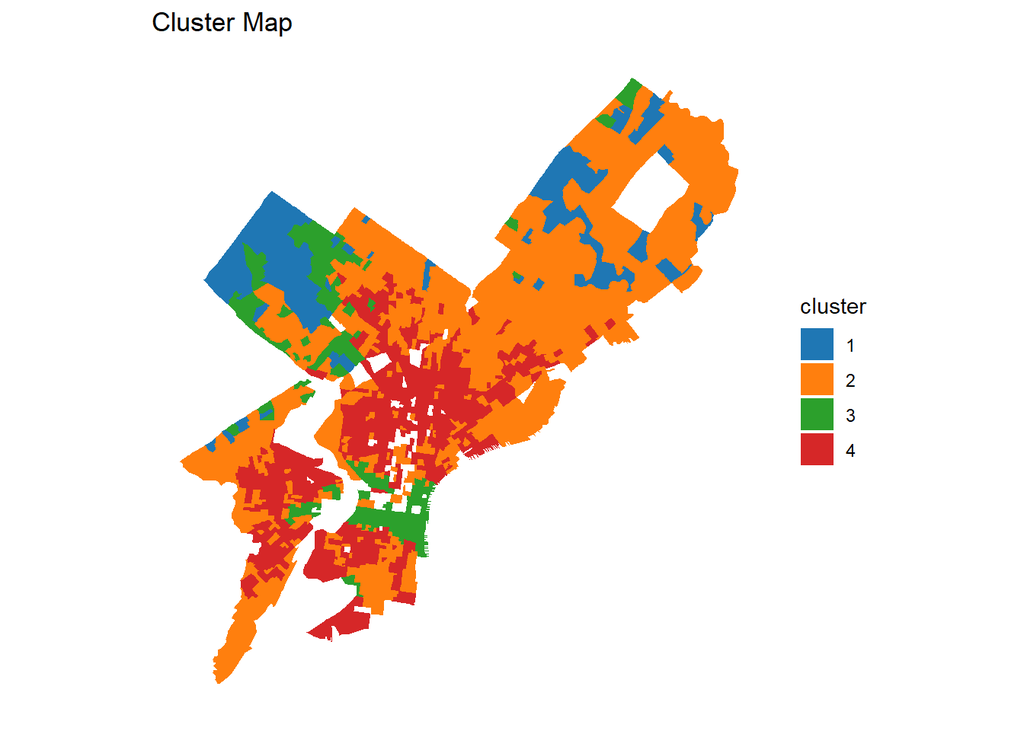

```r
data$cluster <- fit.km$cluster

cluster_shp <- left_join(shp, data, by = "POLY_ID") %>% st_as_sf()

ggplot(cluster_shp) +
  geom_sf(aes(fill = factor(cluster)), color = NA) +
  scale_fill_manual(values = c("#1f77b4", "#ff7f0e", "#2ca02c", "#d62728", "#9467bd", "#8c564b", "#e377c2")) +
  theme_minimal() +
  theme(panel.grid.major = element_blank(),
      panel.grid.minor = element_blank(), # Remove background grid
      axis.text = element_blank(), axis.ticks = element_blank(), # Remove axis text and ticks
      axis.title = element_blank()) + # Remove axis titles
  labs(title = "Cluster Map", fill = "cluster")
```

## 4 Discussion

The k-means analysis of Philadelphia block groups, with its focus on housing values, income levels, educational attainment, and vacancy rates, has unveiled a spatial dimension to the city’s socio-economic stratification. The clusters not only reflect economic status and housing characteristics but also show a geographic cohesion that could inform urban planning and policy decisions. Some key findings in the analysis include: Affluent areas border Wissahickon Park, economically stressed neighborhoods span the north, west, and southwest, and middle-class, education-centric regions are centered around University City. Notably, within various mixed-used neighborhoods with diverse socioeconomic characteristics, some neighborhoods like Fishtown and East Passyunk are transitioning into vibrant hubs for young professionals, indicating a city in socioeconomic flux. This spatial understanding is pivotal for addressing regional disparities and tailoring interventions to the unique needs of each neighborhood, with the potential to foster more equitable and sustainable urban development.